# INFORME - ELECTIVA AREA ELECTRONICA

Santiago Avila, Andres Hernandez, Andres Montenegro, Brayan Zambrano, Nikolas Riapira

2023-05-28

## Supervised Methods in Machine Learning

3rd report guideline: “Supervised learning final project”

*El link al repositorio público de Github es el siguiente: https://github.com/AndresFHernandezJ/AssignmentThree*

## Definicion del problema

Los robots móviles son una solución para la exploración de ambientes hostiles, como lo pueden ser, por ejemplo, ambientes radiactivos o tóxicos, donde la intervención humana directa no es posible. De esta manera se construyó un robot móvil y 3 ambientes diferentes caracterizados por condiciones, las cuales puedan ser sensadas por el robot según los sensores planteados para el mismo.

Para la adquisición de datos se hizo uso de un robot móvil que contó con tres sensores, el sensor de distancia ultrasónico HC-SR04, el sensor de color (RGB)TCS3200 (el cual generaba 3 datos, uno por cada color) y una fotorresistencia para la medición de la intensidad de la luz incidente.

[figure not shown]

HC-SR04 (Imagen tomada de https://ja-bots.com/producto/sensor-hc-sr04-ultrasonico/)

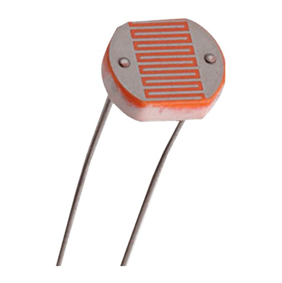

Fotorresistencia (Imagen tomada de https://laelectronica.com.gt/extras/que-es-un-ldr-y-como-funciona

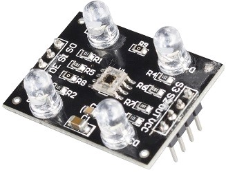

(RGB)TCS3200 (Imagen tomada de http://wiki.sunfounder.cc/index.php?title=TCS3200_Color_Sensor_Module

De esta manera se obtuvo un dataset de 510 observaciones y 6 variable, la primera de ellas fue el valor obtenido por el sensor ultrasónico, la segunda el valor de la fotorresistencia, la tercera el valor correspondiente a la intensidad del color rojo, la cuarta con respecto a la intensidad del color verde, la cuarta relacionada a la intensidad del color azul y por ultimo la variable objetivo, el ambiente.

A continuación se muestra el robot móvil con los sensores el cual mediante programación en el software de Arduino hizo la toma de los datos.

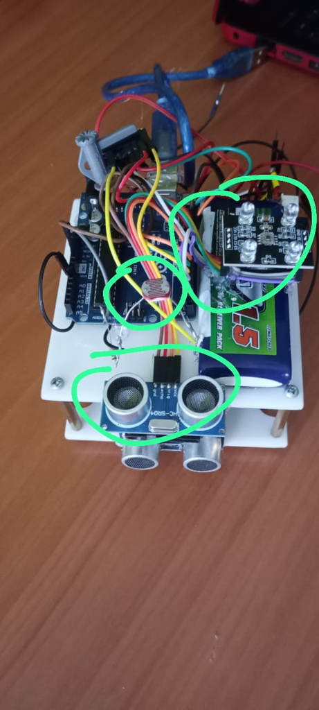

En la siguiente imagen se presentan los 3 ambientes junto con el robot móvil.

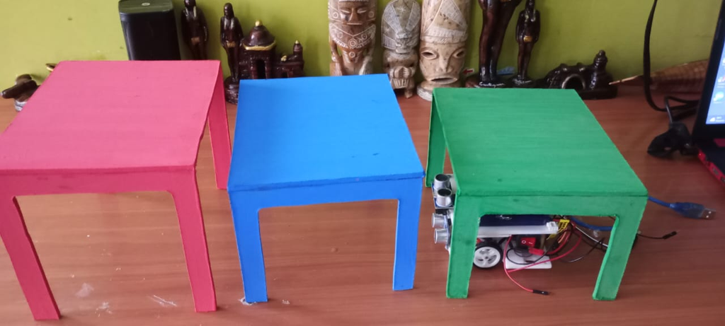

Robot movil

## Analisis exploratorio de datos EDA

No existió un pre procesamiento de los datos con respecto al dataset inicial debido a su estructura, el análisis de datos exploratorio se realizó de la siguiente manera.

El dataset de manera resumida se presenta a continuación.

|  | ultrasonico | fotorresistencia | color1 | color2 | color3 | ambiente |
| --- | --- | --- | --- | --- | --- | --- |
| 1 | 286 | 128 | 750 | 502 | 469 | UNO |
| 2 | 292 | 128 | 748 | 508 | 470 | UNO |
| 3 | 292 | 128 | 747 | 502 | 476 | UNO |
| 4 | 292 | 128 | 748 | 502 | 476 | UNO |
| 5 | 292 | 128 | 753 | 507 | 470 | UNO |
| 6 | 291 | 128 | 749 | 507 | 469 | UNO |

Del cual se puede identificar que cada una de las variables es de tipo int, a excepción de la última la cual es de tipo character y mas o menos se ve la estructura de sus datos, también es posible obtener datos estadísticos como los siguientes.

```
##   ultrasonico    fotorresistencia     color1           color2
##  Min.   :257.0   Min.   :115.0    Min.   : 553.0   Min.   : 488.0
##  1st Qu.:269.2   1st Qu.:119.0    1st Qu.: 634.0   1st Qu.: 513.2
##  Median :369.0   Median :127.0    Median : 760.0   Median : 873.0
##  Mean   :386.1   Mean   :176.8    Mean   : 775.2   Mean   : 804.3
##  3rd Qu.:502.0   3rd Qu.:278.0    3rd Qu.: 946.0   3rd Qu.:1026.8
##  Max.   :576.0   Max.   :337.0    Max.   :1042.0   Max.   :1124.0
##      color3        ambiente
##  Min.   :461.0   Length:510
##  1st Qu.:482.0   Class :character
##  Median :522.0   Mode  :character
##  Mean   :575.9
##  3rd Qu.:727.0
##  Max.   :770.0
```

De esta manera se observa la estructura del dataset, los datos que se obtuvieron con cada uno de los 3 sensores, se observan los valores mínimos, máximos y sus respectivos valores del 25%, 50%, y 75% de los datos.

A continuación se muestra la gráfica relacionando cada una de las variables.

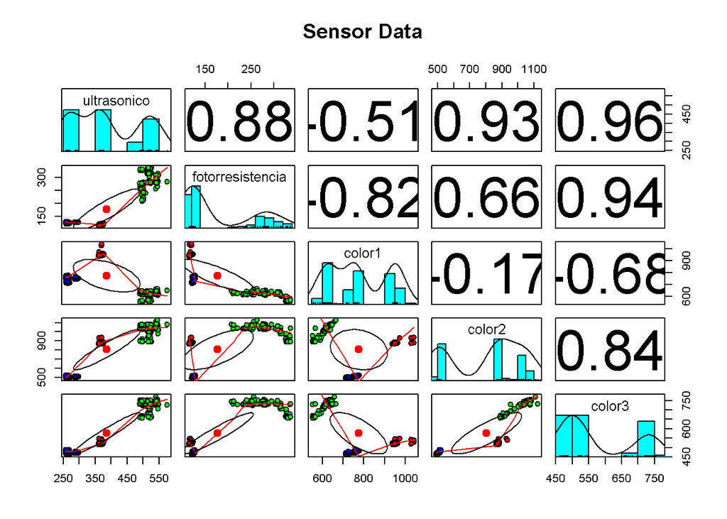

El gráfico anterior es una matriz de dispersión que muestra en su diagonal un histograma de cada variable individual y los gráficos de dispersión entre pares de variables así como la correlación que hay entre ellas.

A continuación se muestran los gráficos de dispersión entre cada una de las variables predictoras vs la variable objetivo.

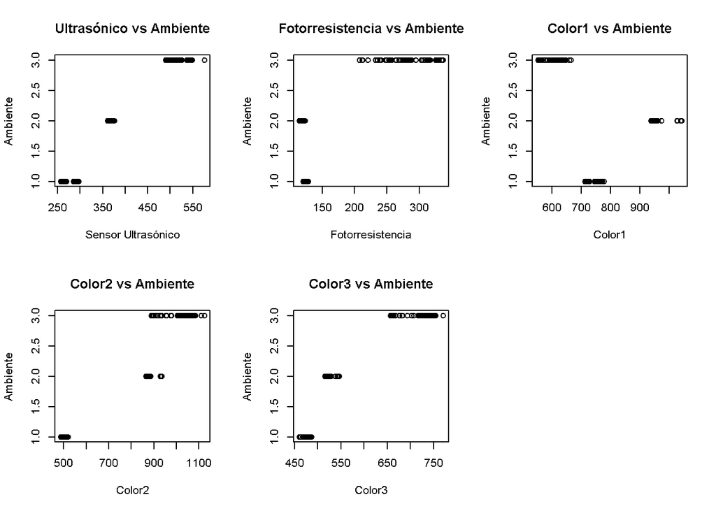

Se observa la relación de dispersión que hay entre cada uno de los sensores con respecto al ambiente en el que fueron tomados los datos, se alcanza a distinguir in tipo de dispersión similar entre los mismos.

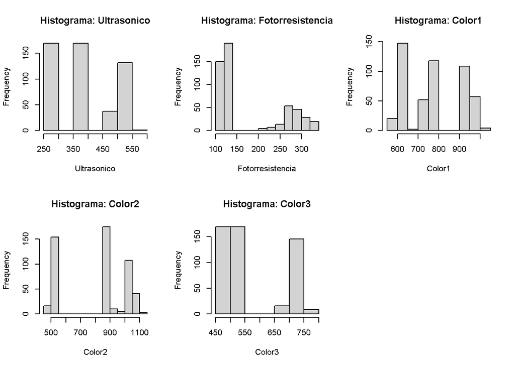

## Métodos de clasificación

```r
Dataset1 <- read.csv("D:/Usr/Desktop/Andres/8vo Semestre/DataScience/AssignmentThree/Datasets/DATA_SET_3_SENSORES.csv")
Dataset1_df <- Dataset1
Dataset1_df$ambiente <- factor(Dataset1_df$ambiente, levels = c("uno", "dos", "tres"))
Dataset1_norm <- Dataset1_df
variables <- c("ultrasonico", "fotorresistencia", "color1", "color2", "color3")
#normalizacion z-score
Dataset1_norm[, variables] <- scale(Dataset1_norm[, variables])
```

Como se observa, se genera un nuevo dataframe llamado Dataset1_norm el cual toma los datos del dataset con la variable factor y los normaliza por el método de Z-Score, finalmente se establecen las variables correspondientes a cada sensor.

Resultando de la siguiente manera:

|  | ultrasonico | fotorresistencia | color1 | color2 | color3 | ambiente |
| --- | --- | --- | --- | --- | --- | --- |
| 1 | -0.9552447 | -0.6206016 | -0.1837503 | -1.370725 | -0.9709900 | NA |
| 2 | -0.8979828 | -0.6206016 | -0.1983110 | -1.343519 | -0.9619082 | NA |
| 3 | -0.8979828 | -0.6206016 | -0.2055913 | -1.370725 | -0.9074172 | NA |
| 4 | -0.8979828 | -0.6206016 | -0.1983110 | -1.370725 | -0.9074172 | NA |
| 5 | -0.8979828 | -0.6206016 | -0.1619093 | -1.348053 | -0.9619082 | NA |
| 6 | -0.9075264 | -0.6206016 | -0.1910306 | -1.348053 | -0.9709900 | NA |

### KNN K-Nearest Neighbors (Vecinos más cercanos)

El método KNN es un método de aprendizaje automático supervisado que se utiliza para la clasificación de datos. La idea inicial de KNN es que los puntos de datos similares tienden a agruparse juntos en el espacio. Por lo tanto, clasifica nuevos puntos de datos con respecto a la clase de los puntos de datos cercanos.

```r
sample.indexA <- sample(1:nrow(Dataset1_norm)
                       ,nrow(Dataset1_norm)*0.7
                       ,replace = F)

predictorsA <- c("ultrasonico", "fotorresistencia", "color1", "color2", "color3")

train.dataA <- Dataset1_norm[sample.indexA
                        ,c(predictorsA,"ambiente")
                        ,drop=F]

test.dataA <- Dataset1_norm[-sample.indexA
                        ,c(predictorsA,"ambiente")
                        ,drop=F]
```

El código anterior es un fragmento de código que se mostrará en cada uno de los modelos debido a que sigue la metodología explicada a continuación que se repite en cada modelo.

A continuación se muestra el código de Knn donde se explica cada linea relevante con un comentario.

## KNN CODIGO

```r
ctrl <- trainControl(method="cv", p=0.7) #Configuración cross-validation 70-30
knnFitAmbiente <- #Modelo
  train(ambiente ~ ultrasonico+fotorresistencia+color1+color2+color3 #Entrenamiento ambiente en función de las variables
                , data = train.dataA #A partir de los datos de entrenamiento (70%)
                , method = "knn" # Método Knn
                , trControl = ctrl #Configuración establecida
                , preProcess = c("center","scale")#Normalización Z-Score
                , tuneLength = 20)

#Salida del modelo
knnFitAmbiente

#Predicciones a partir de los datos de prueba (30%)
knnPredict <- predict(knnFitAmbiente, newdata = test.dataA)

#Matriz de confusión basada en la predicción
confusionMatrix(knnPredict, test.dataA$ambiente)
#Cross table similar a la matriz
CrossTable(test.dataA$ambiente, knnPredict, prop.chisq = FALSE)


saveRDS(knnFitAmbiente, "knn_model.rds")#Codigo para guardar el modelo entrenado.
```

El cual genera la siguiente información donde es posible observar los datos correspondientes al sample, los 5 predictores, las 3 clases, el pre procesamiento (Z-Score) y las cross validación correspondiente a 10 fold.

Tambien se observa la alta precisión obtenida, practicamente perfecta, con un valor de 1.

[output not shown]

```
## Confusion Matrix and Statistics
##
##           Reference
## Prediction UNO DOS TRES
##       UNO   49   0    0
##       DOS    0  51    0
##       TRES   0   0   53
##
## Overall Statistics
##
##                Accuracy : 1
##                  95% CI : (0.9762, 1)
##     No Information Rate : 0.3464
##     P-Value [Acc > NIR] : < 2.2e-16
##
##                   Kappa : 1
##
##  Mcnemar's Test P-Value : NA
##
## Statistics by Class:
##
##                      Class: UNO Class: DOS Class: TRES
## Sensitivity              1.0000     1.0000      1.0000
## Specificity              1.0000     1.0000      1.0000
## Pos Pred Value           1.0000     1.0000      1.0000
## Neg Pred Value           1.0000     1.0000      1.0000
## Prevalence               0.3203     0.3333      0.3464
## Detection Rate           0.3203     0.3333      0.3464
## Detection Prevalence     0.3203     0.3333      0.3464
## Balanced Accuracy        1.0000     1.0000      1.0000
```

Finalmente se muestra la matriz de confusión y sus estadísticas donde también se presenta una predicción perfecta.

Al finalizar y haber guardado el modelo en el archivo .rds, se generaron (para cada uno de los modelos) un nuevo Script para tratar nuevos datos, el cual carga el modelo guardado, obtiene los nuevos, los normaliza y finalmente realiza las predicciones y genera los resultados obtenidos con los nuevos datos.

A continuación se muestra el código correspondiente.

```r
#Se carga el modelo guardado en la variable NewKnnFit
NewknnFitAmbiente <- readRDS("knn_model.rds")
#Se asignan los nuevos datos a la variable nuevos_datos1_norm
nuevos_datos1_norm <- PruebaNuevos
#Se normalizan los datos a través de Z-Score
nuevos_datos1_norm[, variables] <- scale(nuevos_datos1_norm[, variables])
#Se establece la variable ambiente como factor y se organizan los niveles
nuevos_datos1_norm$ambiente <- factor(nuevos_datos1_norm$ambiente, levels = c("UNO", "DOS", "TRES"))
#Se realizan las nuevas predicciones
predicciones1 <- predict(NewknnFitAmbiente, newdata = nuevos_datos1_norm)
#se verifican los resultados
CrossTable(nuevos_datos1_norm$ambiente, predicciones1, prop.chisq = FALSE)
```

### Logistic Regression

La Regresión Logística es un método utilizado para predecir una variable categórica binaria (como “Sí/No”) en función de un conjunto de variables predictoras. Se basa en el modelo logit, que relaciona las probabilidades de la variable dependiente con las variables independientes.

Como se explicó en el modelo de KNN el código inicial de la configuración de los datos entre entrenamiento y prueba es el mismo y maneja la misma metodología anteriormente explicada.

A continuación se muestra el código de logistic regression donde se explica cada linea relevante con un comentario, se debe tener en cuenta que, debido a que la variable ambiente cuenta con mas de 2 niveles, se establece un metodo multinomial y no binomial.

## Logistic Regression Codigo

```r
#Igualmente se toma las muestras aleatorias y se divide en datos de entrenamiento (70%) y datos de prueba (30%)
#################################################################
Sample.indexA2 <- sample(1:nrow(Dataset1_norm)
                        ,nrow(Dataset1_norm)*0.7
                        ,replace = F)

predictorsA2 <- c("ultrasonico", "fotorresistencia", "color1", "color2", "color3")

train.dataA2 <- Dataset1_norm[sample.indexA2
                           ,c(predictorsA,"ambiente")
                           ,drop=F]

test.dataA2 <- Dataset1_norm[-sample.indexA2
                          ,c(predictorsA,"ambiente")
                          ,drop=F]

#################################################################
#Se crea la configuración para el modelo, Repeated cross-validation con 20 repeticiones, 10 folds
fit.control <- trainControl(method = "repeatedcv"
                            ,number = 10, repeats = 20)
#Se entrena el modelo, ambiente en funcion de los valoes de los sensores
LRfit <- train(ambiente ~ ultrasonico + fotorresistencia + color1 + color2 + color3
                     ,data = train.dataA2 #Datos de entrenamiento
                     ,method = "multinom" #Metodo multinomial debido a los 3 niveles de la variable objetivo
                     ,trControl = fit.control #Asigna la configuracion establecida
                      , trace = FALSE)
#Se llama el modelo
LRfit
#Se realizan las predicciones con los datos de prueba de tipo probabilistico
LRPredict <- predict(LRfit, test.dataA2, type = "prob")
#Se llama a las predicciones
LRPredict
#Resumen de los resultados
summary(LRfit)

saveRDS(LRfit, "LR_model.rds")#Se guarda el modelo entrenado
```

El modelo LRfit mostro la siguiente información:

```
## Penalized Multinomial Regression
##
## 357 samples
##   5 predictor
##   3 classes: 'UNO', 'DOS', 'TRES'
##
## No pre-processing
## Resampling: Cross-Validated (10 fold, repeated 20 times)
## Summary of sample sizes: 322, 322, 321, 321, 321, 322, ...
## Resampling results across tuning parameters:
##
##   decay  Accuracy  Kappa
##   0e+00  1         1
##   1e-04  1         1
##   1e-01  1         1
##
## Accuracy was used to select the optimal model using the largest value.
## The final value used for the model was decay = 0.1.
```

Y las predicciones de tipo probabilistico arrojaron la siguiente tabla.

|  | UNO | DOS | TRES |
| --- | --- | --- | --- |
| 2 | 9.946884e-01 | 3.476750e-03 | 1.834879e-03 |
| 6 | 9.947737e-01 | 3.467290e-03 | 1.759035e-03 |
| 10 | 9.952113e-01 | 3.163816e-03 | 1.624873e-03 |
| 12 | 9.948721e-01 | 3.265013e-03 | 1.862889e-03 |
| 13 | 9.947516e-01 | 3.395162e-03 | 1.853268e-03 |
| 18 | 9.949585e-01 | 3.183968e-03 | 1.857523e-03 |
| 27 | 9.941676e-01 | 3.814518e-03 | 2.017837e-03 |
| 32 | 9.947333e-01 | 3.428978e-03 | 1.837678e-03 |
| 34 | 9.948539e-01 | 3.455731e-03 | 1.690354e-03 |
| 39 | 9.952547e-01 | 2.951669e-03 | 1.793598e-03 |

[output cut: 143 more lines]

Donde se puede observar el 30% de los datos, correspondientes a los datos de prueba y la probabilidad asignada según la clase, ya sea del ambiente UNO, DOS o TRES, las predicciones fueron perfectas de igual manera, con datos de 99% para cada ambiente y su dato correspondiente.

Igualmente se creó un script para los nuevos datos muy similar al respecto al modelo de Knn.

### Decision Tree

Un Árbol de Decisión (Decision Tree) es un modelo de aprendizaje automático que utiliza una estructura de árbol para tomar decisiones o realizar predicciones. Se basa en el principio de dividir el conjunto de datos en subconjuntos más pequeños y homogéneos mediante la selección de variables y puntos de corte óptimos.

Como se ha venido explicando, en el modelo de KNN y logistic regression el código inicial de la configuración de los datos entre entrenamiento y prueba es el mismo y maneja la misma metodología anteriormente explicada.

A continuación se muestra el código de Decision Tree donde se explica cada linea relevante con un comentario.

## Decision Tree Codigo

```r
library(rpart)
library(rpart.plot)
#Igualmente se toma las muestras aleatorias y se divide en datos de entrenamiento (70%) y datos de prueba (30%)
##########################################################################
sample.indexA3 <- sample(1:nrow(Dataset1_norm)
                        ,nrow(Dataset1_norm)*0.7
                        ,replace = F)

train.dataA3 <- Dataset1_norm[sample.indexA3
                            ,c(predictorsA3,"ambiente")
                             ,drop=F]

test.dataA3 <- Dataset1_norm[-sample.indexA3
                            ,c(predictorsA3,"ambiente")
                            ,drop=F]
##########################################################################
#El modelo arbol_ambiente se crea a partir de la funcion rpart() de la librería rpart la cual funciona como la función train() de los anteriores modelos, con su respectivo data frame de entrenamiento
arbol_ambiente <- rpart(ambiente ~ ultrasonico+fotorresistencia+color1+color2+color3
                        ,data = train.dataA3)
#Se genera una gráfica de árbol
rpart.plot(arbol_ambiente, type = 2, extra = 104)
#Se guarda el modelo
saveRDS(arbol_ambiente, "DT_model.rds")
```

La grafica del arbol generada es la siguiente:

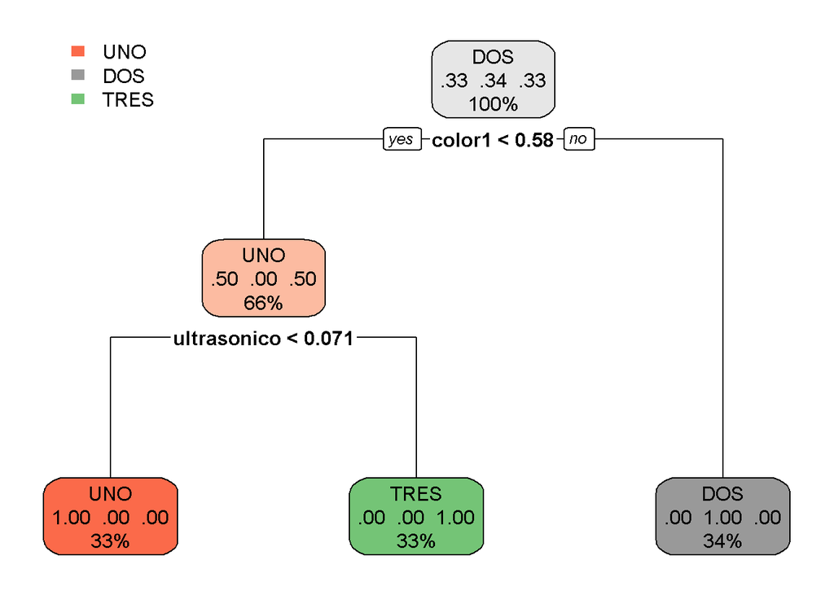

Igualmente se creó un script para los nuevos datos muy similar al respecto al modelo de Knn.